# Incorporating 2020 Data

Erin Johnston

4/12/2021

```r
library(tidyverse)
library(here)
```

Querying the new database for CCFRP information for Cal Poly and Moss Landing Marine Laboratories (MLML) from 2007 to 2020.

Information taken includes: group, trip, drift, area, site, month, day, year, gridcell, species, length, and angler hours.

```r
cp_ml_20 <- read_csv(here("Data","2021-04-12_full_query_2007_2020.csv"))
cp_ml_20 %>%
  select(everything())%>%
  summarise_all(funs(sum(is.na(.))))
```

```
## # A tibble: 1 x 12
##   group  trip drift  area  site month   day  year gridcell species length
##   <int> <int> <int> <int> <int> <int> <int> <int>    <int>   <int>  <int>
## 1     0     0     0     0     0     0     0     0        0       3    165
## # ... with 1 more variable: anglerhours <int>
```

```r
cp_ml_20 <- cp_ml_20 %>% drop_na()

#bluesum <- cp_ml_20 %>% filter(species == "BLU")


life_drifts <- read_csv(here("Data", "2021-04-12_lifetime_drifts_metadata.csv"))
cp_ml_20_sp <- cp_ml_20 %>%
   filter(species %in% c("BLU", "GPR", "BLA", "OLV", "LCD", "VER", "DEA", "YTL",
                         "KLP", "CPR", "CNY", "CHN", "RSY", "BWN", "KGL", "QBK",
                         "CBZ", "BAY", "PSD", "TRE", "SRY"))%>%
  unite(col = spec_size, species:length, sep = "_")



 z_cp_ml <- cp_ml_20_sp %>%
   count(spec_size, drift)%>%
   rename(num_caught = n) %>% ## 72,025 obs 3 vars
   pivot_wider(names_from = drift,
               values_from = num_caught)%>% ## 659 obs 5253 vars
   pivot_longer(-spec_size,
                names_to = "drift",
                values_to = "num_caught") %>%
   mutate(num_caught = case_when(
     is.na(num_caught) ~ 0,
    TRUE ~ as.numeric(num_caught)
   )) ## 3,461,068 obs 3 vars ## YEEEESSS this df is 659*5252

 #sum(length(unique(z_cp_ml$drift)))


 meta_cp_ml <- cp_ml_20_sp %>%
   select(group, trip, area, site, month, day, year, gridcell, anglerhours, drift)%>%
   distinct()

 full_cp_ml <- left_join(z_cp_ml, meta_cp_ml, by = "drift") %>%
   mutate(cpue = num_caught/anglerhours)%>%
   separate(spec_size, into = c("species", "size"), sep = "_") %>%
   rename(site_1 = site)%>%
   transform(site_2 = substr(drift, 3, 3))%>%
   mutate(
     site = case_when(
       site_2 == "M" ~ "MPA",
       site_2 == "R" ~ "REF"))%>%
   select(-site_1, - site_2)%>%
   mutate(size = as.numeric(size))
```

## Incorporate Missing Drifts & MOCI

```r
blue_full <- full_cp_ml %>%
  filter(species == "BLU")


blue_full_drifts <- blue_full %>%
  select(drift)%>%
  distinct

missing_drift <- anti_join(life_drifts, blue_full_drifts, by = "drift")

## the 210 drifts that didn't catch any fish at all. Need to be added to blues each time
add_drifts <- missing_drift %>%
  mutate(species = "BLU",
         num_caught = 0,
         cpue = num_caught/anglerhour)%>%
  rename(anglerhours = anglerhour,
         site_1 = site)%>%
   transform(site_2 = substr(drift, 3, 3))%>%
   mutate(
     site = case_when(
       site_2 == "M" ~ "MPA",
       site_2 == "R" ~ "REF"))%>%
   select(-site_1, - site_2)

## can bind_rows one time and then split by size.
## add_drifts could have been added to full_cp_ml, but then I would need to decide what size to add (potentially NA... not 0). Try this and try to filter by size.
## for now, size filtered and selected off. add_drifts added after size selection
## can you force 'filter' to include NAs from a column. Read about this.

## describe the summarizing using a figure/map show all of the variables for each grouping

juv <- blue_full %>%
  filter(size <= 21) %>%
  select(-size) %>%
  bind_rows(add_drifts)%>%
  group_by(drift, trip, area, site, month, day, year, gridcell) %>%
  summarise(cpue_sum = sum(cpue))%>%
  group_by(trip, area, site, month, day, year, gridcell) %>%
  summarise(cpue_date = mean(cpue_sum))%>%
  group_by( area, site, year, gridcell) %>%
  summarise(cpue_cell = mean(cpue_date))%>%
  group_by( area, site, year) %>%
  summarise(cpue_site = mean(cpue_cell))
## below is the juveniles without adding the 210 drifts. Check to see how much CPUE changes. Look at each of the 0 drifts

juv2 <- blue_full %>%
  filter(size <= 21) %>%
  select(-size) %>%
  #bind_rows(add_drifts)%>%
  group_by(drift, trip, area, site, month, day, year, gridcell) %>%
  summarise(cpue_sum = sum(cpue))%>%
  group_by(trip, area, site, month, day, year, gridcell) %>%
  summarise(cpue_date = mean(cpue_sum))%>%
  group_by( area, site, year, gridcell) %>%
  summarise(cpue_cell = mean(cpue_date))%>%
  group_by( area, site, year) %>%
  summarise(cpue_site = mean(cpue_cell))
## going to write out and add in apppropriate 2007/2015 NA data for BL

#write_csv(juv, here("Data/output", "2021-04-13_juv_blue_site_cpue.csv"))


adult <- blue_full %>%
  filter(size >= 32) %>%
  select(-size)%>%
  bind_rows(add_drifts)%>%
  group_by(drift, trip, area, site, month, day, year, gridcell) %>%
  summarise(cpue_sum = sum(cpue))%>%
  group_by(trip, area, site, month, year, gridcell) %>%
  summarise(cpue_date = mean(cpue_sum)) %>%
  group_by( area, site, year, gridcell) %>%
  summarise(cpue_cell = mean(cpue_date)) %>%
  group_by( area, site, year) %>%
  summarise(cpue_site = mean(cpue_cell))
#write_csv(adult, here("Data/output", "2021-04-13_adult_blue_site_cpue.csv"))
```

```r
juv_na <- read_csv(here("Data", "2021-04-13_juv_blue_site_cpue_NA.csv"))
adult_na <- read_csv(here("Data", "2021-04-13_adult_blue_site_cpue_NA.csv"))
## had to get new MOCI data to include all of 2020
MOCI <- read_csv(here("Data", "Central_California_MOCI_2020.csv"))
juv_moci <- left_join(juv_na, MOCI, by = "year")
adult_moci <- left_join(adult_na, MOCI, by = "year")
```

Cross correlation function

```r
erin_ccf <- function(full_x, full_y, lag_x_rm, lag_y_rm) {
  mean_x <- mean(full_x, na.rm = T)
  mean_y <- mean(full_y, na.rm = T)
  corval <- (sum((lag_x_rm - mean_x)*
                   (lag_y_rm - mean_y)))/
    ((sqrt(sum((full_x - mean_x)^2, na.rm = T)))*
       (sqrt(sum((full_y - mean_y)^2, na.rm = T))))
  return(corval)

}
```

```r
juv_corr <- data.frame(area = character(), site = character(), season = character(), lag = character(), correlation = character())

adult_corr <- data.frame(area = character(), site = character(), season = character(), lag = character(), correlation = character())

area_list <- c("PB", "BL", "AN", "PL")
site_list <- c("MPA", "REF")
season_list <- c("JFM", "AMJ", "JAS", "OND")
```

## Juvenile

```r
for(j in area_list){
  for(k in site_list){
    for(l in season_list){
      juvenile <- juv_moci %>%
        filter(area == j, site == k, season == l)
      for(i in 0:8){
        lag_df <- juvenile %>%
          mutate(central_ca = dplyr::lag(central_ca, n = i)) %>% drop_na()
        cor <- erin_ccf(juvenile$central_ca, juvenile$cpue_site,
                        lag_df$central_ca, lag_df$cpue_site)
        for(m in 1:length(cor)){
          juv_corr <- bind_rows(juv_corr, c(area = j, site = k, season = l,
                                            lag = -i, correlation = cor[m]))
        }
      }
    }
  }
}


juv_vis <- juv_corr %>%
  mutate(correlation = as.numeric(correlation),
         lag = as.numeric(lag))

juv_vis$season <- factor(juv_vis$season, levels = c("JFM", "AMJ" ,"JAS", "OND"))

juv_plot_erin_ccf <- ggplot()+
  scale_color_manual(values = c("#999999", "#009999", "#666666", "#000000"))+
  scale_fill_manual(values = c("#999999", "#009999", "#666666", "#000000"))+
  geom_col(position = "dodge2", data = juv_vis, aes(x = lag, y = correlation,
                                                    color = season, fill = season))+
  labs(title = "Juvenile Blue Rockfish Lag Correlation")+
  theme_bw()+
  theme(panel.grid = element_blank(),
        plot.title = element_text(hjust = 0.5))+
  facet_grid(site~area)

# ggsave("2021-04-14_juv_corr_2020_dat.png", plot = juv_plot_erin_ccf,
#        path = "C:/Users/erinj/Documents/Thesis/Figures/Lag/2021", dpi = 1000, width = 6,
#        height = 4)
```

```r
juv_vis %>%
  arrange(desc(correlation)) %>%
  group_by(area, site) %>%
  slice(1)
```

```
## # A tibble: 8 x 5
## # Groups:   area, site [8]
##   area  site  season   lag correlation
##   <chr> <chr> <fct>  <dbl>       <dbl>
## 1 AN    MPA   JAS       -2       0.894
## 2 AN    REF   JAS       -2       0.869
## 3 BL    MPA   JAS       -2       0.770
## 4 BL    REF   OND       -2       0.788
## 5 PB    MPA   JAS       -2       0.864
## 6 PB    REF   JAS       -2       0.827
## 7 PL    MPA   JAS       -2       0.805
## 8 PL    REF   AMJ       -1       0.571
```

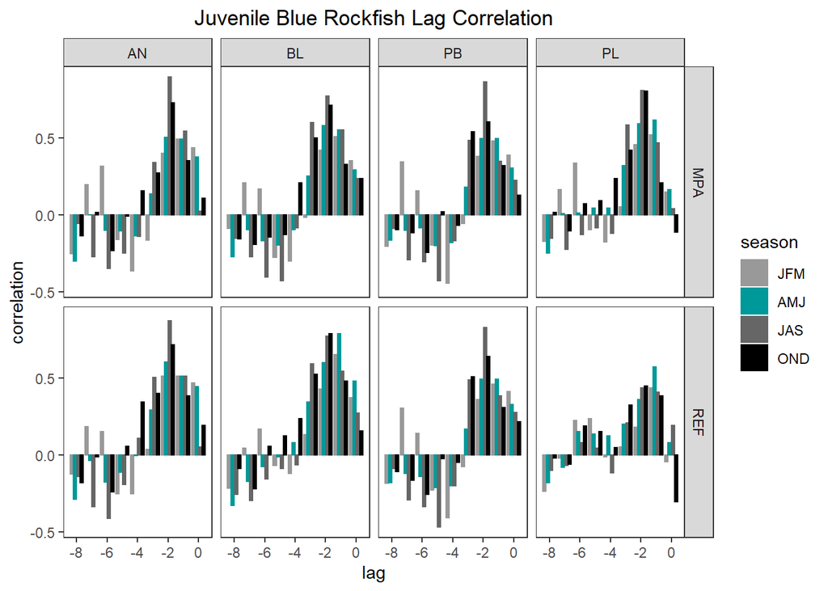

```r
juv_plot_erin_ccf
```

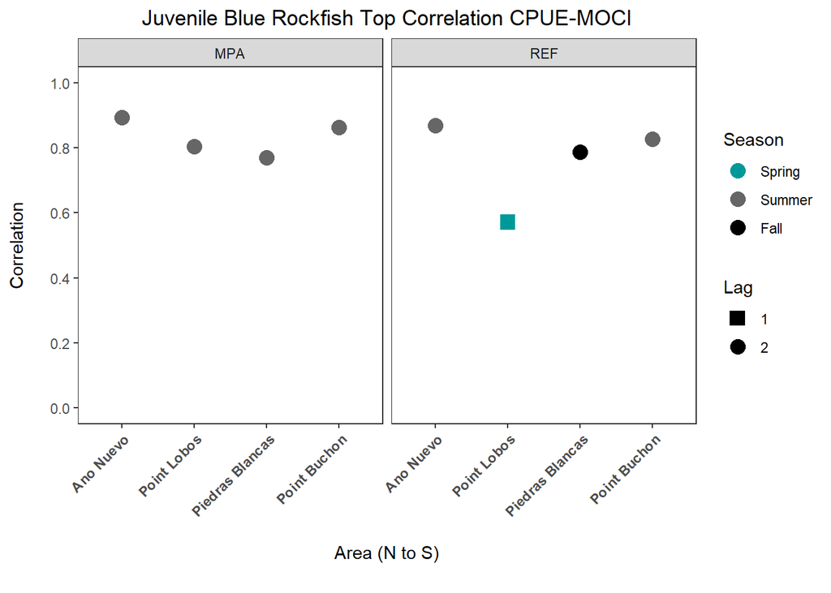

```r
top_juv <- juv_vis %>%
  arrange(desc(correlation)) %>%
  group_by(area, site) %>% slice(1)


top_juv_meeting <- top_juv %>%
  mutate(Season = case_when(
    season == "JFM" ~ "Winter",
    season == "AMJ" ~ "Spring",
    season == "JAS" ~ "Summer",
    season == "OND" ~ "Fall"
  ), Lag = case_when(
    lag == "-2" ~ "2",
    lag == "-1" ~ "1"
  ), Area = case_when(
    area == "AN" ~ "Ano Nuevo",
    area == "PL" ~ "Point Lobos",
    area == "BL" ~ "Piedras Blancas",
    area == "PB" ~ "Point Buchon"
  ))

top_juv_meeting$area <- factor(top_juv_meeting$area, levels = c("AN", "PL", "BL", "PB"))
top_juv_meeting$Area <- factor(top_juv_meeting$Area, levels = c("Ano Nuevo", "Point Lobos", "Piedras Blancas", "Point Buchon"))
top_juv_meeting$Season <- factor(top_juv_meeting$Season,
                                 levels = c("Winter", "Spring", "Summer", "Fall"))


#top_juv_plot <-
top_juv_2020_dat <- top_juv_meeting %>%
  ggplot()+
  geom_point(size = 4, aes(x = Area, y = correlation, color = Season,
                           fill = Season, shape = Lag))+
  scale_color_manual(values = c("#009999","#666666", "#000000"))+
  scale_fill_manual(values = c("#009999", "#666666", "#000000"))+
  scale_shape_manual(values = c(15, 19))+
  labs(title = "Juvenile Blue Rockfish Top Correlation CPUE-MOCI",
       y = "Correlation\n", x = "\nArea (N to S)", caption = "")+
  scale_y_continuous(limits = c(0.0, 1.0),
                     breaks = c(0.0, 0.2, 0.4, 0.6, 0.8, 1.0))+
  facet_wrap(.~site)+
  theme_bw()+
    theme(panel.grid = element_blank(),
          plot.title = element_text(hjust = 0.5),
          plot.caption = element_text(size = 8),
          axis.text.x = element_text(face = "bold",angle = 45, hjust =1))

top_juv_2020_dat
```

```r
# ggsave("2021-04-14_top_juv_2020_dat.png", plot = top_juv_2020_dat,
#        path = "C:/Users/erinj/Documents/Thesis/Figures/Lag/2021", dpi = 1000, width = 6,
#        height = 4)
```

## Adult

Prediction: longer time lags between cpue and MOCI than previously seen because intermediate maturity no longer influencing lags to be close to -2 JAS. Due to potentially being higher in the food chain - see life history excel for prey info. Still think response will be positive correlation. Think this will have to do with timing as effect radiate through food chain. I predict more consistency between areas and sites with the new size cutoff, the way that cutting to just immature fish for juvs had consisten results.

```r
for(j in area_list){
  for(k in site_list){
    for(l in season_list){
      adult <- adult_moci %>%
        filter(area == j, site == k, season == l)
      for(i in 0:8){
        lag_df <- adult %>%
          mutate(central_ca = dplyr::lag(central_ca, n = i)) %>% drop_na()
        cor <- erin_ccf(adult$central_ca, adult$cpue_site,
                        lag_df$central_ca, lag_df$cpue_site)
        for(m in 1:length(cor)){
          adult_corr <- bind_rows(adult_corr, c(area = j, site = k, season = l,
                                            lag = -i, correlation = cor[m]))
        }
      }
    }
  }
}



adult_vis <- adult_corr %>%
  mutate(correlation = as.numeric(correlation),
         lag = as.numeric(lag))

adult_vis$season <- factor(adult_vis$season, levels = c("JFM", "AMJ" ,"JAS", "OND"))

adult_plot_erin_ccf <- ggplot()+
  scale_color_manual(values = c("#999999", "#009999", "#666666", "#000000"))+
  scale_fill_manual(values = c("#999999", "#009999", "#666666", "#000000"))+
  geom_col(position = "dodge2", data = adult_vis, aes(x = lag, y = correlation,
                                                      color = season, fill = season))+
  labs(title = "Adult Blue Rockfish Lag Correlation")+
  theme_bw()+
  theme(panel.grid = element_blank(),
        plot.title = element_text(hjust = 0.5))+
  facet_grid(site~area)

# ggsave("2021-04-14_adult_corr_2020_dat.png", plot = adult_plot_erin_ccf,
#        path = "C:/Users/erinj/Documents/Thesis/Figures/Lag/2021", dpi = 1000, width = 6,
#        height = 4)
```

```r
adult_vis %>%
  arrange(desc(correlation)) %>%
  group_by(area, site) %>%
  slice(1)
```

```
## # A tibble: 8 x 5
## # Groups:   area, site [8]
##   area  site  season   lag correlation
##   <chr> <chr> <fct>  <dbl>       <dbl>
## 1 AN    MPA   JAS       -1       0.729
## 2 AN    REF   JAS       -2       0.675
## 3 BL    MPA   AMJ       -1       0.718
## 4 BL    REF   AMJ       -1       0.777
## 5 PB    MPA   AMJ       -1       0.852
## 6 PB    REF   OND       -3       0.603
## 7 PL    MPA   AMJ       -1       0.650
## 8 PL    REF   JAS        0       0.634
```

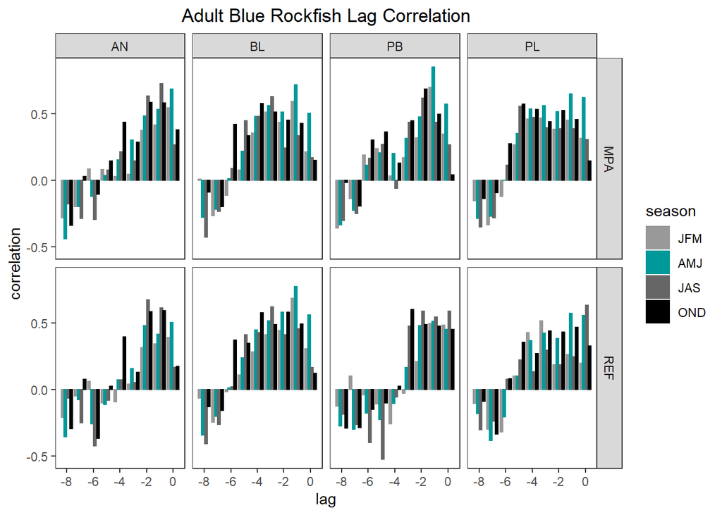

```r
adult_plot_erin_ccf
```

```r
top_adult <- adult_vis %>%
  arrange(desc(correlation)) %>%
  group_by(area, site) %>% slice(1)


top_adult_meeting <- top_adult %>%
  mutate(Season = case_when(
    season == "JFM" ~ "Winter",
    season == "AMJ" ~ "Spring",
    season == "JAS" ~ "Summer",
    season == "OND" ~ "Fall"
  ), Lag = case_when(
    lag == "0" ~ "0",
    lag == "-1" ~ "1",
    lag == "-2" ~ "2",
    lag == "-3" ~ "3",
    lag == "-4" ~ "4"
  ), Area = case_when(
    area == "AN" ~ "Ano Nuevo",
    area == "PL" ~ "Point Lobos",
    area == "BL" ~ "Piedras Blancas",
    area == "PB" ~ "Point Buchon"
  ))

top_adult_meeting$area <- factor(top_adult_meeting$area, levels = c("AN", "PL", "BL", "PB"))
top_adult_meeting$Area <- factor(top_adult_meeting$Area, levels = c("Ano Nuevo", "Point Lobos", "Piedras Blancas", "Point Buchon"))
top_adult_meeting$Season <- factor(top_adult_meeting$Season,
                                 levels = c("Winter", "Spring", "Summer", "Fall"))
#top_adult_meeting$Lag <- factor(top_adult_meeting$Lag, levels = c(0, 1, 2, 3, 4, 5, 6, 7, 8, 9, 10))


#top_adult_plot <-
top_adult_2020_dat <-  top_adult_meeting %>%
  #mutate(lag = as.factor(lag))%>%
  ggplot()+
  geom_point(size = 4, aes(x = Area, y = correlation,
                           color = Season, fill = Season, shape = Lag))+
  scale_color_manual(values = c("#009999","#666666", "#000000"))+
  scale_fill_manual(values = c( "#009999","#666666", "#000000"))+
  scale_shape_manual(values = c(18, 15, 19, 17))+
  labs(title = "Adult Blue Rockfish Top Correlation CPUE-MOCI", y = "Correlation\n",
       x = "\nArea (N to S)", caption = "")+
  scale_y_continuous(limits = c(0.0, 1.0),
                     breaks = c(0.0, 0.2, 0.4, 0.6, 0.8, 1.0))+
  facet_wrap(.~site)+
  theme_bw()+
    theme(panel.grid=element_blank(),
          plot.title = element_text(hjust = 0.5),
          plot.caption = element_text(size = 8),
          axis.text.x = element_text(face = "bold",angle = 45, hjust =1))

#
# ggsave("2021-04-14_top_adult_2020_dat.png", plot = top_adult_2020_dat,
#        path = "C:/Users/erinj/Documents/Thesis/Figures/Lag/2021", dpi = 1000, width = 6,
#        height = 4)
```

Wellll - that prediction did not hold at all. I must not be considering the right factors here. In the MPA, consistent 1 year lag, in either the spring or summer. In REF, no consistency at all, one lag of every kind.

Ben - consistency MPA? Hunter - figure: side by side corr bars MPA vs REF from same area. Stop at 4(?) lags instead of 8. Grant has thoughts: can we look at MPA REF cpue trendlines by area as proxy for MPA effects?

## Missing Heatwave Years

Taking out all CPUE & MOCI data from 2014, 2015, 2016. Doing this shoud wipe out the 2 year lag correlation if the juvenile abundance is in response to things happening during MHW. Basically, if the MHW is driving this relationship, we shoul see less of a relationship.

```r
#write_csv(juv_moci, here("Data/output", "2021-04-13_juv_moci_na.csv"))

juv_no_mhw <- read_csv(here("Data", "2021-04-13_juv_moci_na_no_mhw.csv"))
```

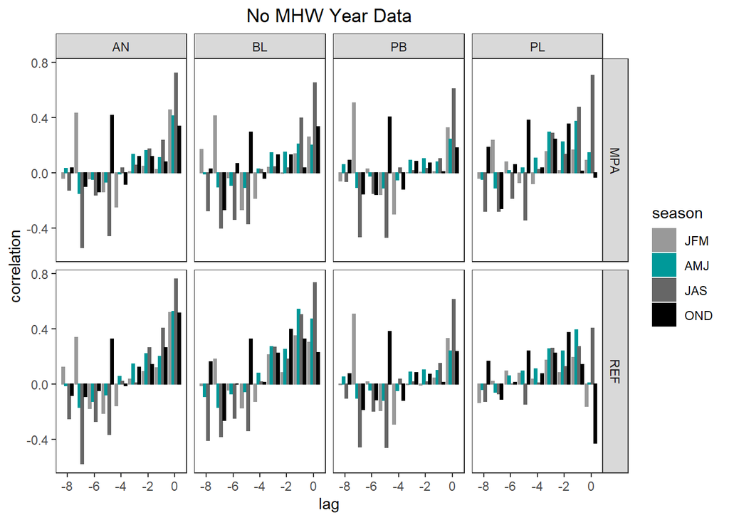

```r
juv_corr_no_mhw <- data.frame(area = character(), site = character(), season = character(), lag = character(), correlation = character())

for(j in area_list){
  for(k in site_list){
    for(l in season_list){
      juvenile <- juv_no_mhw %>%
        filter(area == j, site == k, season == l)
      for(i in 0:8){
        lag_df <- juvenile %>%
          mutate(central_ca = dplyr::lag(central_ca, n = i)) %>% drop_na()
        #juvenile2 <- juvenile %>% drop_na()
        cor <- erin_ccf(juvenile$central_ca, juvenile$cpue_site,
                        lag_df$central_ca, lag_df$cpue_site)
        for(m in 1:length(cor)){
          juv_corr_no_mhw <- bind_rows(juv_corr_no_mhw, c(area = j, site = k, season = l,
                                            lag = -i, correlation = cor[m]))
        }
      }
    }
  }
}

juv_vis_no_mhw <- juv_corr_no_mhw %>%
  mutate(correlation = as.numeric(correlation),
         lag = as.numeric(lag))

juv_vis_no_mhw$season <- factor(juv_vis_no_mhw$season, levels = c("JFM", "AMJ" ,"JAS", "OND"))

juv_plot_no_mhw <- ggplot()+
  scale_color_manual(values = c("#999999", "#009999", "#666666", "#000000"))+
  scale_fill_manual(values = c("#999999", "#009999", "#666666", "#000000"))+
  geom_col(position = "dodge2", data = juv_vis_no_mhw, aes(x = lag, y = correlation, color = season, fill = season))+
  labs(title = "No MHW Year Data")+
  theme_bw()+
  theme(panel.grid = element_blank(),
        plot.title = element_text(hjust = 0.5))+
  facet_grid(site~area)

juv_plot_no_mhw
```

## Missing Three Random Years

Taking out all CPUE & MOCI data from 2009-2011. Taking out a random subset of three consecutive years that are *not* marine heatwave years, should mean that the correlation is not completely gone. I would expect to still see a two-ish year lag for many of the area+ site combinations for juv blue rockfish if the MHW are driving the relationship, since those years are still included.

```r
juv_no_9_11 <- read_csv(here("Data", "2021-04-13_juv_moci_na_no_09-11.csv"))
```

```r
juv_corr_no_9_11 <- data.frame(area = character(), site = character(), season = character(), lag = character(), correlation = character())

for(j in area_list){
  for(k in site_list){
    for(l in season_list){
      juvenile <- juv_no_9_11 %>%
        filter(area == j, site == k, season == l)
      for(i in 0:8){
        lag_df <- juvenile %>%
          mutate(central_ca = dplyr::lag(central_ca, n = i)) %>% drop_na()
        #juvenile2 <- juvenile %>% drop_na()
        cor <- erin_ccf(juvenile$central_ca, juvenile$cpue_site,
                        lag_df$central_ca, lag_df$cpue_site)
        for(m in 1:length(cor)){
          juv_corr_no_9_11 <- bind_rows(juv_corr_no_9_11, c(area = j, site = k, season = l,
                                            lag = -i, correlation = cor[m]))
        }
      }
    }
  }
}

juv_vis_no_9_11 <- juv_corr_no_9_11 %>%
  mutate(correlation = as.numeric(correlation),
         lag = as.numeric(lag))

juv_vis_no_9_11$season <- factor(juv_vis_no_9_11$season, levels = c("JFM", "AMJ" ,"JAS", "OND"))

no9_11<- ggplot()+
  scale_color_manual(values = c("#999999", "#009999", "#666666", "#000000"))+
  scale_fill_manual(values = c("#999999", "#009999", "#666666", "#000000"))+
  geom_col(position = "dodge2", data = juv_vis_no_9_11, aes(x = lag, y = correlation, color = season, fill = season))+
  labs(title = "No 2009-2011 Data")+
  theme_bw()+
  theme(panel.grid = element_blank(),
        plot.title = element_text(hjust = 0.5))+
  facet_grid(site~area)

juv_vis_no_9_11 %>%
  arrange(desc(correlation)) %>%
  group_by(area, site) %>%
  slice(1)
```

```
## # A tibble: 8 x 5
## # Groups:   area, site [8]
##   area  site  season   lag correlation
##   <chr> <chr> <fct>  <dbl>       <dbl>
## 1 AN    MPA   JAS       -2       0.828
## 2 AN    REF   JAS       -2       0.771
## 3 BL    MPA   JAS       -2       0.627
## 4 BL    REF   JFM       -1       0.737
## 5 PB    MPA   JAS       -2       0.789
## 6 PB    REF   JAS       -2       0.741
## 7 PL    MPA   JAS       -2       0.680
## 8 PL    REF   JFM       -1       0.427
```

## No 2007-2009

Ben Notes: Take out all combos of three years that are not considered part of the marine heatwave. Why am I doing this? Ask in meeting

```r
juv_no_7_9 <- read_csv(here("Data", "2021-04-13_juv_moci_na_no_07-09.csv"))
```

```r
juv_corr_no_7_9 <- data.frame(area = character(), site = character(), season = character(), lag = character(), correlation = character())

for(j in area_list){
  for(k in site_list){
    for(l in season_list){
      juvenile <- juv_no_7_9 %>%
        filter(area == j, site == k, season == l)
      for(i in 0:8){
        lag_df <- juvenile %>%
          mutate(central_ca = dplyr::lag(central_ca, n = i)) %>% drop_na()
        #juvenile2 <- juvenile %>% drop_na()
        cor <- erin_ccf(juvenile$central_ca, juvenile$cpue_site,
                        lag_df$central_ca, lag_df$cpue_site)
        for(m in 1:length(cor)){
          juv_corr_no_7_9 <- bind_rows(juv_corr_no_7_9, c(area = j, site = k, season = l,
                                            lag = -i, correlation = cor[m]))
        }
      }
    }
  }
}

juv_vis_no_7_9 <- juv_corr_no_7_9 %>%
  mutate(correlation = as.numeric(correlation),
         lag = as.numeric(lag))

juv_vis_no_7_9$season <- factor(juv_vis_no_7_9$season, levels = c("JFM", "AMJ" ,"JAS", "OND"))

no7_9 <- ggplot()+
  scale_color_manual(values = c("#999999", "#009999", "#666666", "#000000"))+
  scale_fill_manual(values = c("#999999", "#009999", "#666666", "#000000"))+
  geom_col(position = "dodge2", data = juv_vis_no_7_9, aes(x = lag, y = correlation, color = season, fill = season))+
  labs(title = "No 2007-2009 Data")+
  theme_bw()+
  theme(panel.grid = element_blank(),
        plot.title = element_text(hjust = 0.5))+
  facet_grid(site~area)
```

## No 2008-2010

```r
juv_no_8_10 <- read_csv(here("Data", "2021-04-13_juv_moci_na_no_08-10.csv"))
```

```r
juv_corr_no_8_10 <- data.frame(area = character(), site = character(), season = character(), lag = character(), correlation = character())

for(j in area_list){
  for(k in site_list){
    for(l in season_list){
      juvenile <- juv_no_8_10 %>%
        filter(area == j, site == k, season == l)
      for(i in 0:8){
        lag_df <- juvenile %>%
          mutate(central_ca = dplyr::lag(central_ca, n = i)) %>% drop_na()
        #juvenile2 <- juvenile %>% drop_na()
        cor <- erin_ccf(juvenile$central_ca, juvenile$cpue_site,
                        lag_df$central_ca, lag_df$cpue_site)
        for(m in 1:length(cor)){
          juv_corr_no_8_10 <- bind_rows(juv_corr_no_8_10, c(area = j, site = k, season = l,
                                            lag = -i, correlation = cor[m]))
        }
      }
    }
  }
}

juv_vis_no_8_10 <- juv_corr_no_8_10 %>%
  mutate(correlation = as.numeric(correlation),
         lag = as.numeric(lag))

juv_vis_no_8_10$season <- factor(juv_vis_no_8_10$season, levels = c("JFM", "AMJ" ,"JAS", "OND"))

no8_10 <- ggplot()+
  scale_color_manual(values = c("#999999", "#009999", "#666666", "#000000"))+
  scale_fill_manual(values = c("#999999", "#009999", "#666666", "#000000"))+
  geom_col(position = "dodge2", data = juv_vis_no_8_10, aes(x = lag, y = correlation, color = season, fill = season))+
  labs(title = "No 2008-2010 Data")+
  theme_bw()+
  theme(panel.grid = element_blank(),
        plot.title = element_text(hjust = 0.5))+
  facet_grid(site~area)
```

## No 2010-2012

```r
juv_no_10_12 <- read_csv(here("Data", "2021-04-13_juv_moci_na_no_10-12.csv"))
```

```r
juv_corr_no_10_12 <- data.frame(area = character(), site = character(), season = character(), lag = character(), correlation = character())

for(j in area_list){
  for(k in site_list){
    for(l in season_list){
      juvenile <- juv_no_10_12 %>%
        filter(area == j, site == k, season == l)
      for(i in 0:8){
        lag_df <- juvenile %>%
          mutate(central_ca = dplyr::lag(central_ca, n = i)) %>% drop_na()
        #juvenile2 <- juvenile %>% drop_na()
        cor <- erin_ccf(juvenile$central_ca, juvenile$cpue_site,
                        lag_df$central_ca, lag_df$cpue_site)
        for(m in 1:length(cor)){
          juv_corr_no_10_12 <- bind_rows(juv_corr_no_10_12, c(area = j, site = k, season = l,
                                            lag = -i, correlation = cor[m]))
        }
      }
    }
  }
}

juv_vis_no_10_12 <- juv_corr_no_10_12 %>%
  mutate(correlation = as.numeric(correlation),
         lag = as.numeric(lag))

juv_vis_no_10_12$season <- factor(juv_vis_no_10_12$season, levels = c("JFM", "AMJ" ,"JAS", "OND"))

no10_12 <- ggplot()+
  scale_color_manual(values = c("#999999", "#009999", "#666666", "#000000"))+
  scale_fill_manual(values = c("#999999", "#009999", "#666666", "#000000"))+
  geom_col(position = "dodge2", data = juv_vis_no_10_12, aes(x = lag, y = correlation, color = season, fill = season))+
  labs(title = "No 2010-2012 Data")+
  theme_bw()+
  theme(panel.grid = element_blank(),
        plot.title = element_text(hjust = 0.5))+
  facet_grid(site~area)
```

## No 2011-2013

```r
juv_no_11_13 <- read_csv(here("Data", "2021-04-13_juv_moci_na_no_11-13.csv"))
```

```r
juv_corr_no_11_13 <- data.frame(area = character(), site = character(), season = character(), lag = character(), correlation = character())

for(j in area_list){
  for(k in site_list){
    for(l in season_list){
      juvenile <- juv_no_11_13 %>%
        filter(area == j, site == k, season == l)
      for(i in 0:8){
        lag_df <- juvenile %>%
          mutate(central_ca = dplyr::lag(central_ca, n = i)) %>% drop_na()
        #juvenile2 <- juvenile %>% drop_na()
        cor <- erin_ccf(juvenile$central_ca, juvenile$cpue_site,
                        lag_df$central_ca, lag_df$cpue_site)
        for(m in 1:length(cor)){
          juv_corr_no_11_13 <- bind_rows(juv_corr_no_11_13, c(area = j, site = k, season = l,
                                            lag = -i, correlation = cor[m]))
        }
      }
    }
  }
}

juv_vis_no_11_13 <- juv_corr_no_11_13 %>%
  mutate(correlation = as.numeric(correlation),
         lag = as.numeric(lag))

juv_vis_no_11_13$season <- factor(juv_vis_no_11_13$season, levels = c("JFM", "AMJ" ,"JAS", "OND"))

no11_13 <- ggplot()+
  scale_color_manual(values = c("#999999", "#009999", "#666666", "#000000"))+
  scale_fill_manual(values = c("#999999", "#009999", "#666666", "#000000"))+
  geom_col(position = "dodge2", data = juv_vis_no_11_13, aes(x = lag, y = correlation, color = season, fill = season))+
  labs(title = "No 2011-2013 Data")+
  theme_bw()+
  theme(panel.grid = element_blank(),
        plot.title = element_text(hjust = 0.5))+
  facet_grid(site~area)
```

## No 2017-2019

```r
juv_no_17_19 <- read_csv(here("Data", "2021-04-13_juv_moci_na_no_17-19.csv"))
```

```r
juv_corr_no_17_19 <- data.frame(area = character(), site = character(), season = character(), lag = character(), correlation = character())

for(j in area_list){
  for(k in site_list){
    for(l in season_list){
      juvenile <- juv_no_17_19 %>%
        filter(area == j, site == k, season == l)
      for(i in 0:8){
        lag_df <- juvenile %>%
          mutate(central_ca = dplyr::lag(central_ca, n = i)) %>% drop_na()
        #juvenile2 <- juvenile %>% drop_na()
        cor <- erin_ccf(juvenile$central_ca, juvenile$cpue_site,
                        lag_df$central_ca, lag_df$cpue_site)
        for(m in 1:length(cor)){
          juv_corr_no_17_19 <- bind_rows(juv_corr_no_17_19, c(area = j, site = k, season = l,
                                            lag = -i, correlation = cor[m]))
        }
      }
    }
  }
}

juv_vis_no_17_19 <- juv_corr_no_17_19 %>%
  mutate(correlation = as.numeric(correlation),
         lag = as.numeric(lag))

juv_vis_no_17_19$season <- factor(juv_vis_no_17_19$season, levels = c("JFM", "AMJ" ,"JAS", "OND"))

no17_19 <- ggplot()+
  scale_color_manual(values = c("#999999", "#009999", "#666666", "#000000"))+
  scale_fill_manual(values = c("#999999", "#009999", "#666666", "#000000"))+
  geom_col(position = "dodge2", data = juv_vis_no_17_19, aes(x = lag, y = correlation, color = season, fill = season))+
  labs(title = "No 2017-2019 Data")+
  theme_bw()+
  theme(panel.grid = element_blank(),
        plot.title = element_text(hjust = 0.5))+
  facet_grid(site~area)
```

## No 2018-2020

```r
juv_no_18_20 <- read_csv(here("Data", "2021-04-13_juv_moci_na_no_18-20.csv"))
```

```r
juv_corr_no_18_20 <- data.frame(area = character(), site = character(), season = character(), lag = character(), correlation = character())

for(j in area_list){
  for(k in site_list){
    for(l in season_list){
      juvenile <- juv_no_18_20 %>%
        filter(area == j, site == k, season == l)
      for(i in 0:8){
        lag_df <- juvenile %>%
          mutate(central_ca = dplyr::lag(central_ca, n = i)) %>% drop_na()
        #juvenile2 <- juvenile %>% drop_na()
        cor <- erin_ccf(juvenile$central_ca, juvenile$cpue_site,
                        lag_df$central_ca, lag_df$cpue_site)
        for(m in 1:length(cor)){
          juv_corr_no_18_20 <- bind_rows(juv_corr_no_18_20, c(area = j, site = k, season = l,
                                            lag = -i, correlation = cor[m]))
        }
      }
    }
  }
}

juv_vis_no_18_20 <- juv_corr_no_18_20 %>%
  mutate(correlation = as.numeric(correlation),
         lag = as.numeric(lag))

juv_vis_no_18_20$season <- factor(juv_vis_no_18_20$season, levels = c("JFM", "AMJ" ,"JAS", "OND"))

no18_20 <- ggplot()+
  scale_color_manual(values = c("#999999", "#009999", "#666666", "#000000"))+
  scale_fill_manual(values = c("#999999", "#009999", "#666666", "#000000"))+
  geom_col(position = "dodge2", data = juv_vis_no_18_20, aes(x = lag, y = correlation, color = season, fill = season))+
  labs(title = "No 2018-2020 Data")+
  theme_bw()+
  theme(panel.grid = element_blank(),
        plot.title = element_text(hjust = 0.5))+
  facet_grid(site~area)
```

## All Missing Year Figures

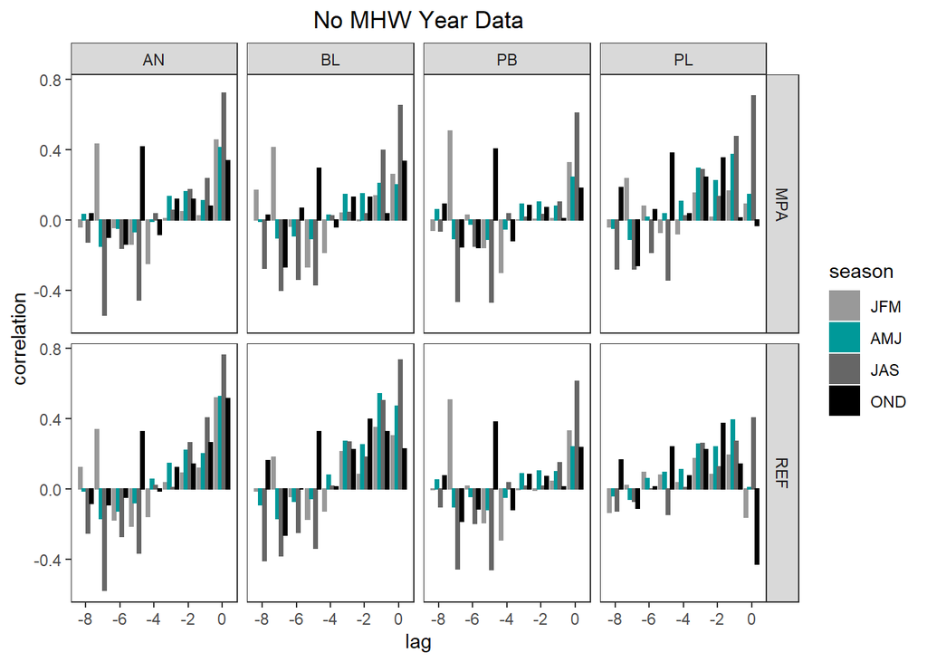

```r
juv_plot_no_mhw
```

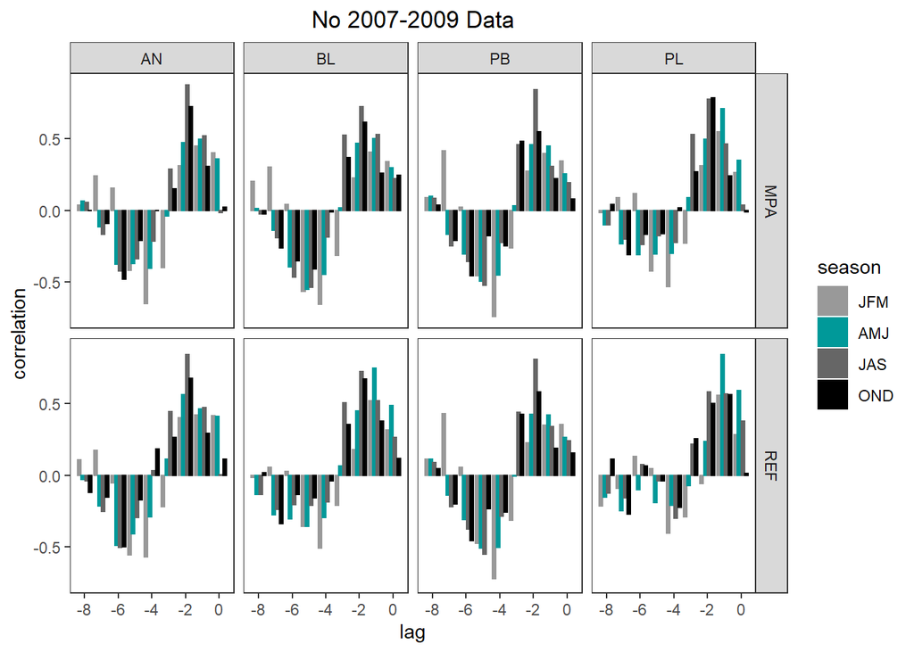

```r
no7_9
```

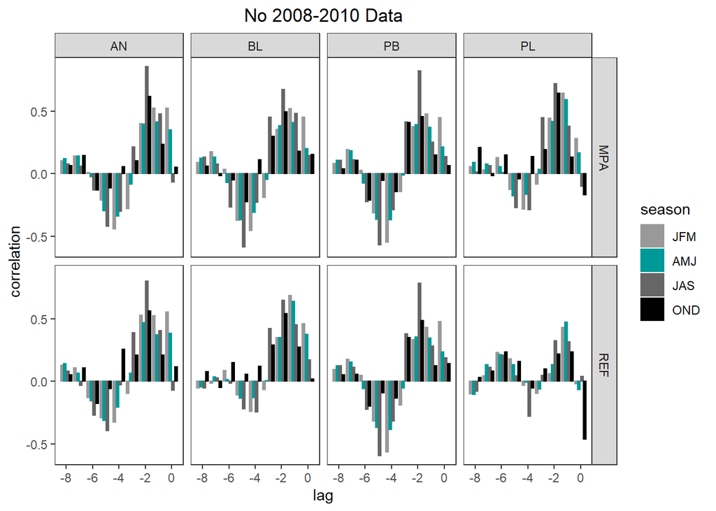

```r
no8_10
```

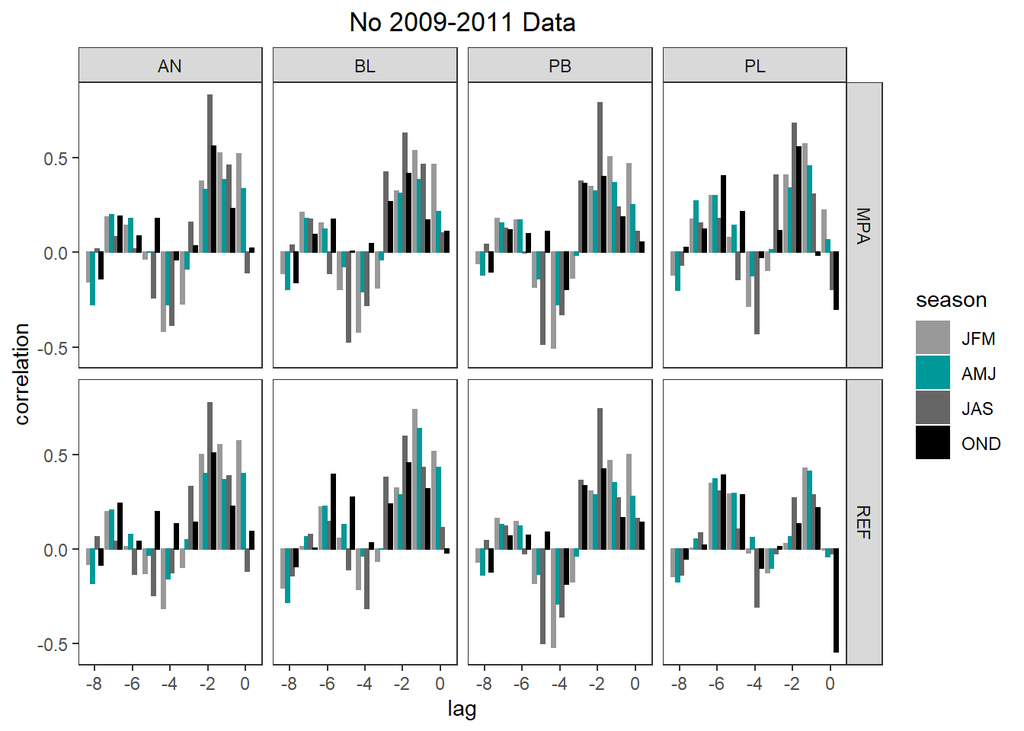

```r
no9_11
```

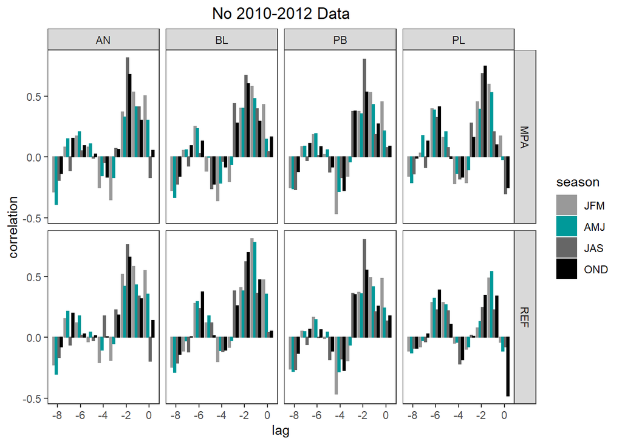

```r
no10_12
```

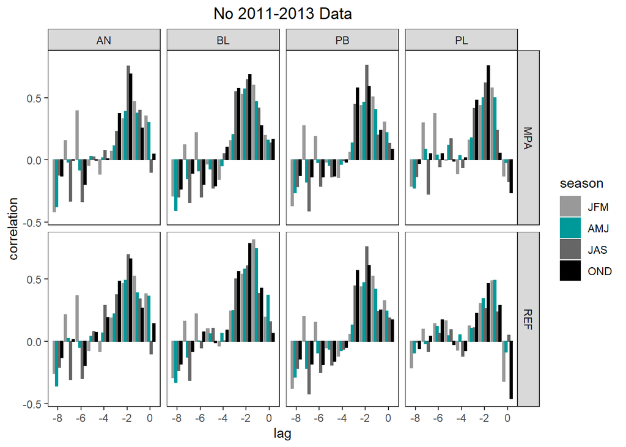

```r
no11_13
```

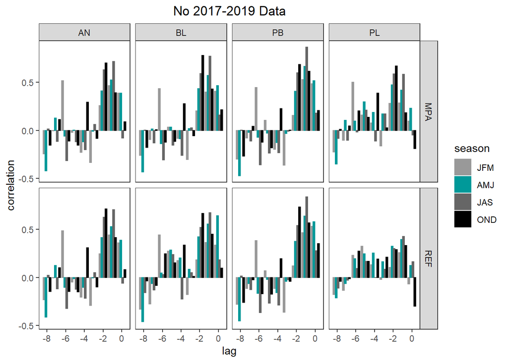

```r
no17_19
```

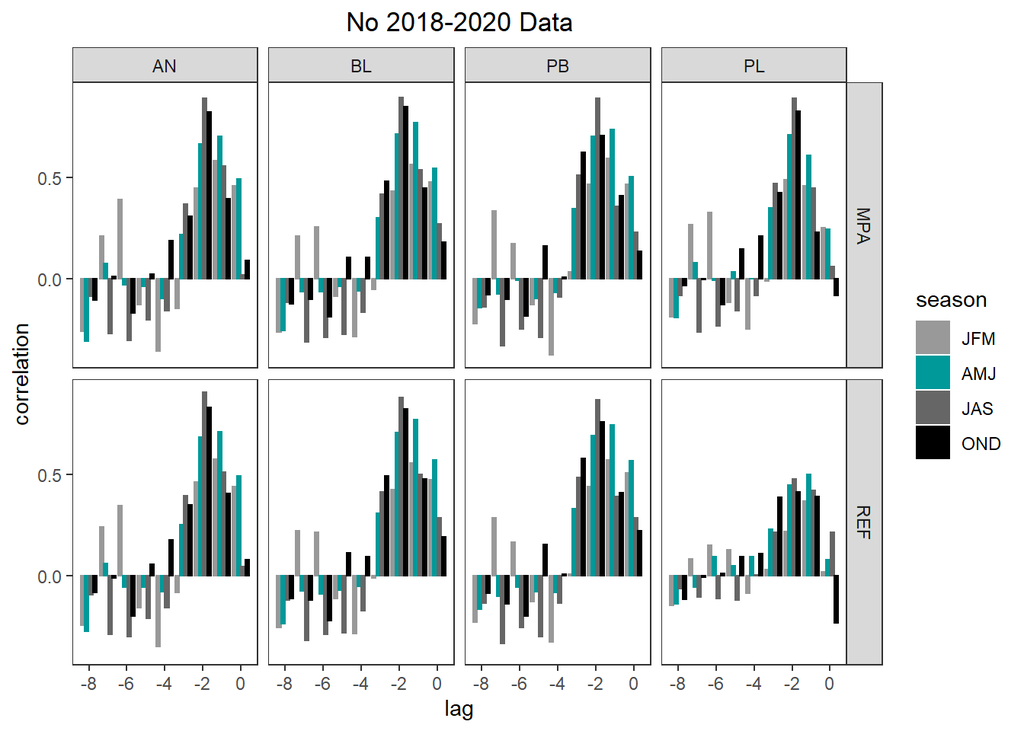

```r
no18_20
```

```r
miss_yr <- juv_vis_no_mhw %>%
  arrange(desc(correlation)) %>%
  group_by(area, site) %>% slice(1)


miss_yr <- miss_yr %>%
  mutate(Season = case_when(
    season == "JFM" ~ "Winter",
    season == "AMJ" ~ "Spring",
    season == "JAS" ~ "Summer",
    season == "OND" ~ "Fall"
  ), Lag = case_when(
    lag == "-2" ~ "2",
    lag == "-1" ~ "1"
  ), Area = case_when(
    area == "AN" ~ "Ano Nuevo",
    area == "PL" ~ "Point Lobos",
    area == "BL" ~ "Piedras Blancas",
    area == "PB" ~ "Point Buchon"
  ))

miss_yr$area <- factor(miss_yr$area, levels = c("AN", "PL", "BL", "PB"))
miss_yr$Area <- factor(miss_yr$Area, levels = c("Ano Nuevo", "Point Lobos", "Piedras Blancas", "Point Buchon"))
miss_yr$Season <- factor(miss_yr$Season,
                                 levels = c("Winter", "Spring", "Summer", "Fall"))



miss_years_plot <- miss_yr %>%
  ggplot()+
  geom_point(size = 4, aes(x = Area, y = correlation, color = Season,
                           fill = Season, shape = Lag))+
  scale_color_manual(values = c("#009999","#666666", "#000000"))+
  scale_fill_manual(values = c("#009999", "#666666", "#000000"))+
  scale_shape_manual(values = c(15, 19))+
  labs(title = "Juvenile Blue Rockfish Top Correlation CPUE-MOCI",
       y = "Correlation\n", x = "\nArea (N to S)", caption = "")+
  scale_y_continuous(limits = c(0.0, 1.0),
                     breaks = c(0.0, 0.2, 0.4, 0.6, 0.8, 1.0))+
  facet_wrap(.~site)+
  theme_bw()+
    theme(panel.grid = element_blank(),
          plot.title = element_text(hjust = 0.5),
          plot.caption = element_text(size = 8),
          axis.text.x = element_text(face = "bold",angle = 45, hjust =1))

ggsave("2021-04-14_no18_20.png", plot = miss_years_plot,
        path = "C:/Users/erinj/Documents/Thesis/Figures/Lag/2021", dpi = 1000, width = 6,
        height = 4)
```

2021-04-13 Notes Considerations of other things that are different during MHW years. Think more about this. Human activity changes as a result of MHW? Maybe in REF. Not in MPA. Vet this: infilling? maybe averages. See if this pattern holds. Because having three years absent is a lot.

Next steps predictions Run with LCD and VER

Grants brilliant thought: if this comes to fishing.size cutoff for CPOP data for avoidinng smaller blues. Think about cutoffs from fishing perspective instead of life history. Thing of lings. legal sizes instead of life history sizes. below 56cm not legal. Use low cutoff for juve… 50(?)… adults upper limit. Run 3rd CCF with open areas and the legal size 56cm. If sublegal looks like MPA, and legal looks like REF?

Blues CPOP kept vs release. as a proxy for “legal” same idea as above.

## Supplement - No 2020 Data (Previous Work)

Juv without 2020, but everything else is same

```r
juv_na_19 <- juv_na %>%
  filter(year != 2020)

juv_moci_19 <- left_join(juv_na_19, MOCI, by = "year")

juv_corr_19 <- data.frame(area = character(), site = character(), season = character(), lag = character(), correlation = character())

for(j in area_list){
  for(k in site_list){
    for(l in season_list){
      juvenile <- juv_moci_19 %>%
        filter(area == j, site == k, season == l)
      for(i in 0:8){
        lag_df <- juvenile %>%
          mutate(central_ca = dplyr::lag(central_ca, n = i)) %>% drop_na()
        cor <- erin_ccf(juvenile$central_ca, juvenile$cpue_site,
                        lag_df$central_ca, lag_df$cpue_site)
        for(m in 1:length(cor)){
          juv_corr_19 <- bind_rows(juv_corr_19, c(area = j, site = k, season = l,
                                            lag = -i, correlation = cor[m]))
        }
      }
    }
  }
}

juv_vis_19 <- juv_corr_19 %>%
  mutate(correlation = as.numeric(correlation),
         lag = as.numeric(lag))

juv_vis_19$season <- factor(juv_vis_19$season, levels = c("JFM", "AMJ" ,"JAS", "OND"))


juv_vis_19 %>%
  arrange(desc(correlation)) %>%
  group_by(area, site) %>%
  slice(1)
```

```
## # A tibble: 8 x 5
## # Groups:   area, site [8]
##   area  site  season   lag correlation
##   <chr> <chr> <fct>  <dbl>       <dbl>
## 1 AN    MPA   JAS       -2       0.894
## 2 AN    REF   JAS       -2       0.872
## 3 BL    MPA   JAS       -2       0.770
## 4 BL    REF   JAS       -2       0.817
## 5 PB    MPA   JAS       -2       0.865
## 6 PB    REF   JAS       -2       0.830
## 7 PL    MPA   JAS       -2       0.834
## 8 PL    REF   JAS       -2       0.468
```

Adults without 2020 but everything else is same

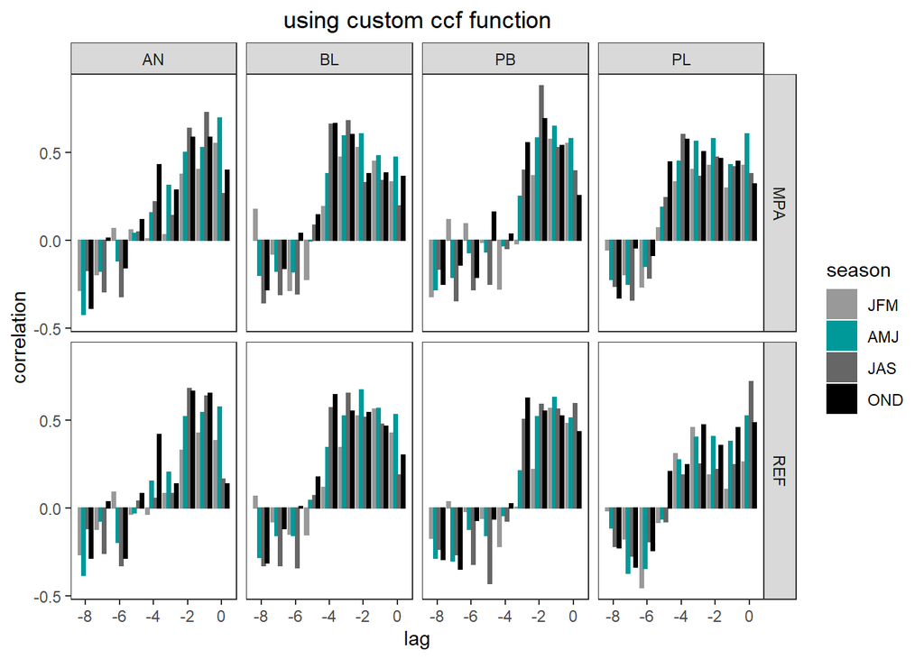

```r
adult_na_19 <- adult_na %>%
  filter(year != 2020)

adult_moci_19 <- left_join(adult_na_19, MOCI, by = "year")

adult_corr_19 <- data.frame(area = character(), site = character(), season = character(), lag = character(), correlation = character())

for(j in area_list){
  for(k in site_list){
    for(l in season_list){
      adult <- adult_moci_19 %>%
        filter(area == j, site == k, season == l)
      for(i in 0:8){
        lag_df <- adult %>%
          mutate(central_ca = dplyr::lag(central_ca, n = i)) %>% drop_na()
        cor <- erin_ccf(adult$central_ca, adult$cpue_site,
                        lag_df$central_ca, lag_df$cpue_site)
        for(m in 1:length(cor)){
          adult_corr_19 <- bind_rows(adult_corr_19, c(area = j, site = k, season = l,
                                            lag = -i, correlation = cor[m]))
        }
      }
    }
  }
}

adult_vis_19 <- adult_corr_19 %>%
  mutate(correlation = as.numeric(correlation),
         lag = as.numeric(lag))

adult_vis_19$season <- factor(adult_vis_19$season, levels = c("JFM", "AMJ" ,"JAS", "OND"))

ggplot()+
  scale_color_manual(values = c("#999999", "#009999", "#666666", "#000000"))+
  scale_fill_manual(values = c("#999999", "#009999", "#666666", "#000000"))+
  geom_col(position = "dodge2", data = adult_vis_19, aes(x = lag, y = correlation, color = season, fill = season))+
  labs(title = "using custom ccf function")+
  theme_bw()+
  theme(panel.grid = element_blank(),
        plot.title = element_text(hjust = 0.5))+
  facet_grid(site~area)
```

```r
adult_vis_19 %>%
  arrange(desc(correlation)) %>%
  group_by(area, site) %>%
  slice(1)
```

```
## # A tibble: 8 x 5
## # Groups:   area, site [8]
##   area  site  season   lag correlation
##   <chr> <chr> <fct>  <dbl>       <dbl>
## 1 AN    MPA   JAS       -1       0.727
## 2 AN    REF   JAS       -2       0.680
## 3 BL    MPA   JAS       -3       0.679
## 4 BL    REF   AMJ       -2       0.674
## 5 PB    MPA   JAS       -2       0.878
## 6 PB    REF   AMJ       -1       0.628
## 7 PL    MPA   AMJ        0       0.606
## 8 PL    REF   JAS        0       0.717
```